# Utilisation de Strava chez les coureurs amateurs

#### SCORE EXPOSITION

| Variable | Moyenne | Médiane | Ecart_type |
| --- | --- | --- | --- |
| Activités | 2.421476 | 2 | 0.5482822 |
| Horaires | 2.323490 | 2 | 0.6275903 |
| Fréquence cardiaque | 2.151678 | 2 | 0.7583411 |
| Allure | 2.365101 | 2 | 0.6031867 |
| Départ et arrivée | 1.851007 | 2 | 0.8250625 |
| Entraînement | 3.528859 | 4 | 0.7438182 |
| Compétition | 3.719463 | 4 | 0.7552396 |
| Nommage activité | 2.775235 | 3 | 0.9681340 |
| Commentaire activité | 2.259758 | 2 | 0.8506116 |
| Photo activité | 2.252022 | 2 | 0.6871404 |
| Total | 25.655870 | 26 | 4.3157861 |

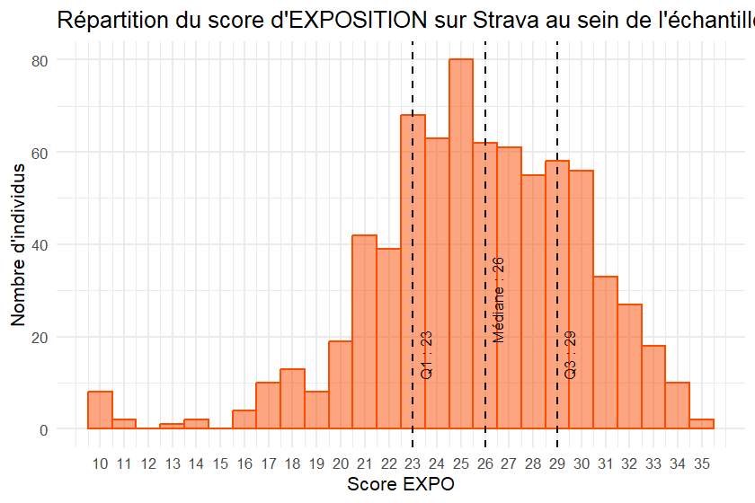

### Autres mesures

#### Catégorie d’abonnement

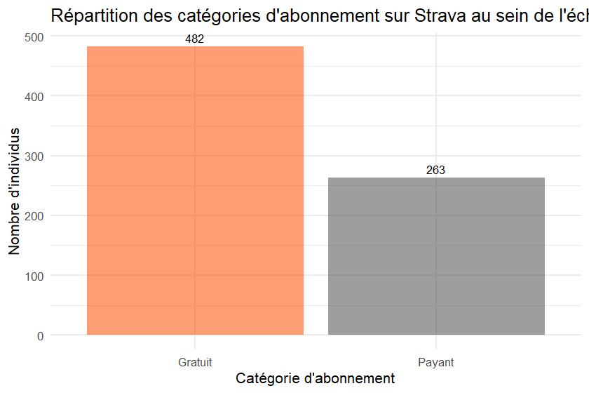

#### Ancienneté sur Strava

| Moyenne | Médiane | Ecart_type |
| --- | --- | --- |
| 4.864065 | 5 | 2.918311 |

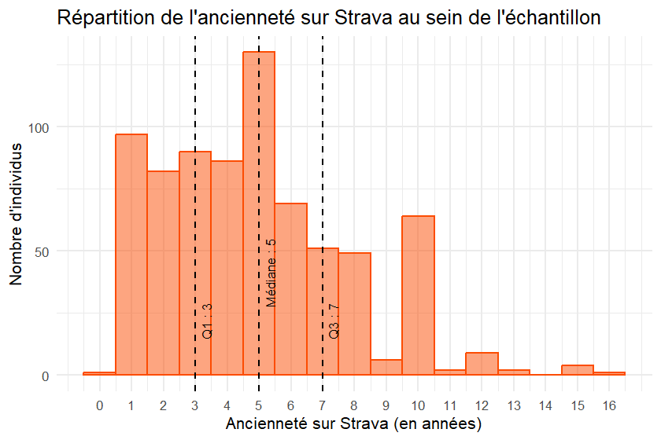

#### Buts utilisation Strava

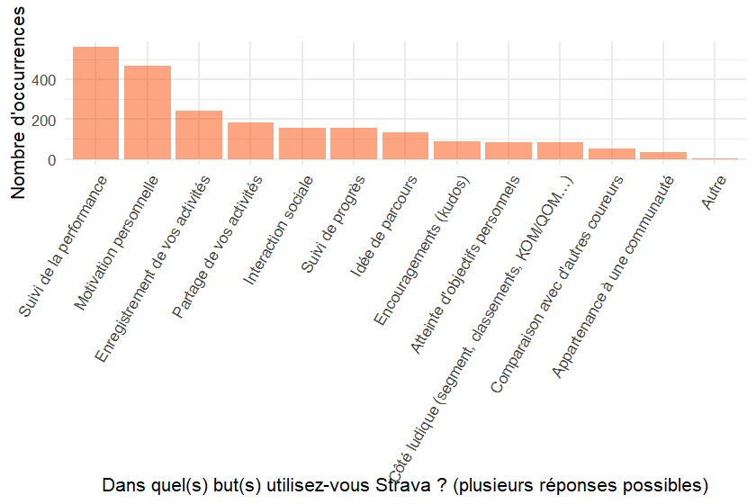

#### Fonctionnalité la plus utile dans la pratique

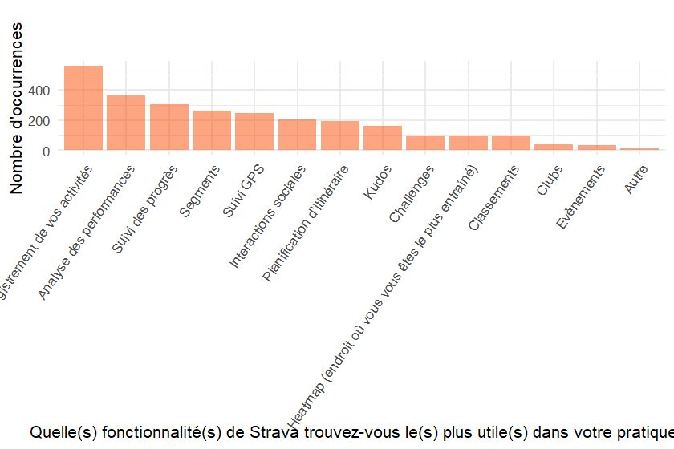

#### Restriction abonnés

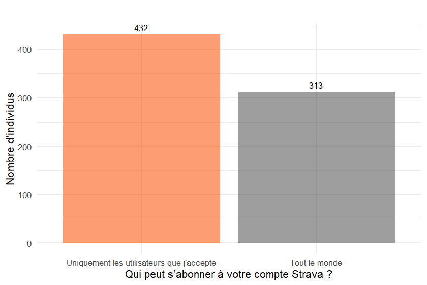

#### Désabonnement

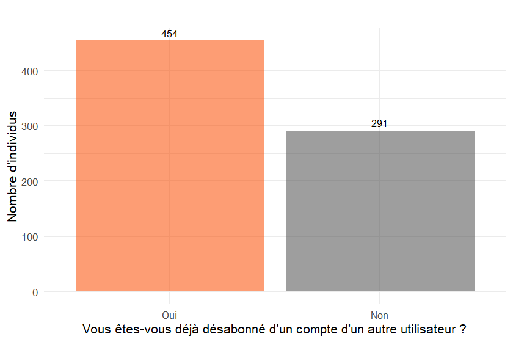

#### Blocage

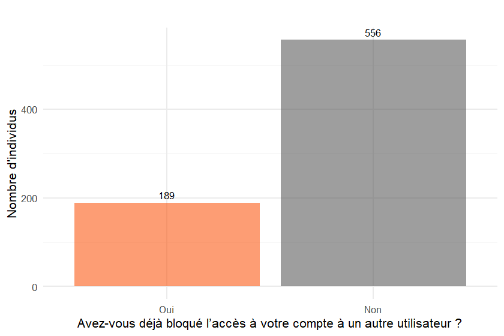

```
## Le nombre d'individus considérés 189.
```

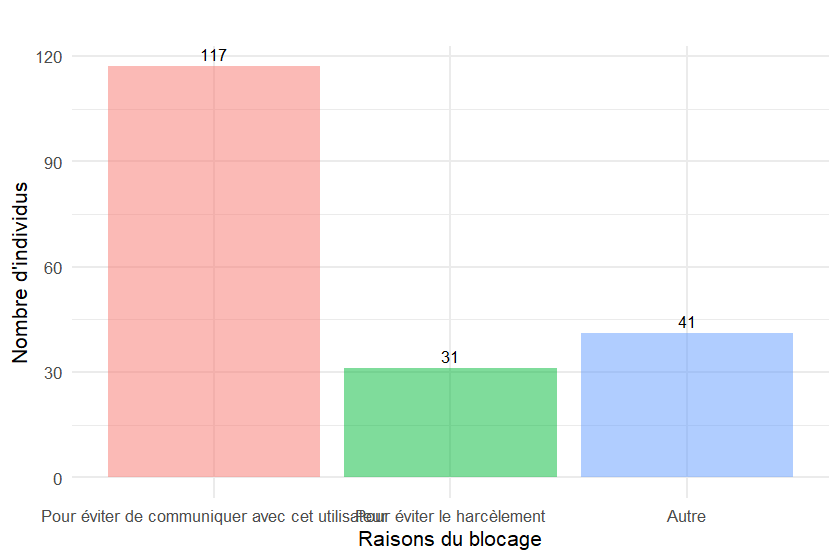

#### Type d’abonnés

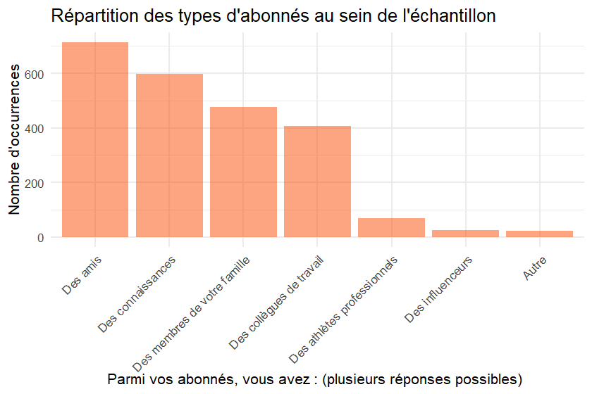

#### Type d’abonnements suivis

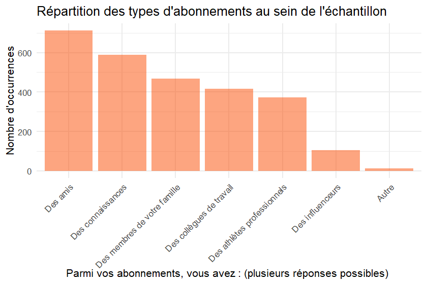

### Corrélations

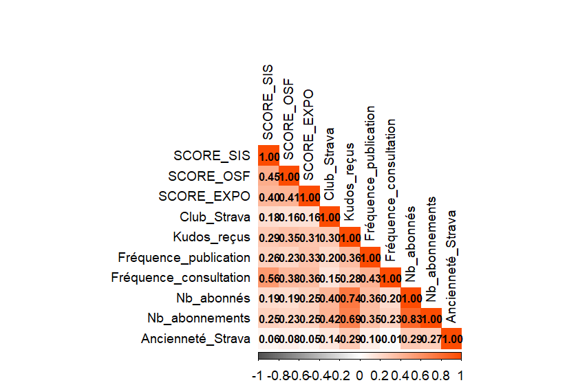

```
##
##
## |                       |SCORE_SIS      |SCORE_OSF      |SCORE_EXPO     |Club_Strava    |Kudos_reçus    |Fréquence_publication |Fréquence_consultation |Nb_abonnés     |Nb_abonnements |Ancienneté_Strava |
## |:----------------------|:--------------|:--------------|:--------------|:--------------|:--------------|:---------------------|:----------------------|:--------------|:--------------|:-----------------|
## |SCORE_SIS              |1.00           |               |               |               |               |                      |                       |               |               |                  |
## |SCORE_OSF              |0.45 (p=0.000) |1.00           |               |               |               |                      |                       |               |               |                  |
## |SCORE_EXPO             |0.40 (p=0.000) |0.41 (p=0.000) |1.00           |               |               |                      |                       |               |               |                  |
## |Club_Strava            |0.18 (p=0.000) |0.16 (p=0.000) |0.16 (p=0.000) |1.00           |               |                      |                       |               |               |                  |
## |Kudos_reçus            |0.29 (p=0.000) |0.35 (p=0.000) |0.31 (p=0.000) |0.30 (p=0.000) |1.00           |                      |                       |               |               |                  |
## |Fréquence_publication  |0.26 (p=0.000) |0.23 (p=0.000) |0.33 (p=0.000) |0.20 (p=0.000) |0.36 (p=0.000) |1.00                  |                       |               |               |                  |
## |Fréquence_consultation |0.56 (p=0.000) |0.38 (p=0.000) |0.36 (p=0.000) |0.15 (p=0.000) |0.28 (p=0.000) |0.43 (p=0.000)        |1.00                   |               |               |                  |
## |Nb_abonnés             |0.19 (p=0.000) |0.19 (p=0.000) |0.25 (p=0.000) |0.40 (p=0.000) |0.74 (p=0.000) |0.36 (p=0.000)        |0.20 (p=0.000)         |1.00           |               |                  |
## |Nb_abonnements         |0.25 (p=0.000) |0.23 (p=0.000) |0.25 (p=0.000) |0.42 (p=0.000) |0.69 (p=0.000) |0.35 (p=0.000)        |0.23 (p=0.000)         |0.83 (p=0.000) |1.00           |                  |
## |Ancienneté_Strava      |0.06 (p=0.129) |0.08 (p=0.033) |0.05 (p=0.183) |0.14 (p=0.000) |0.29 (p=0.000) |0.10 (p=0.011)        |-0.01 (p=0.747)        |0.29 (p=0.000) |0.27 (p=0.000) |1.00              |
```

[output not shown]

[output cut: 25 more lines]

[output not shown]

# Lien données socio-démographiques - utilisation de Strava

### Age - Strava

La question est de savoir ici s’il existe des liens entre l’âge et l’utilisation de Strava.

On peut tester les liens entre les variables Strava suivantes et l’âge :

- Score SIS
- Score OSF
- Score exposition
- Appartenance à des clubs Strava
- Nombre de kudos reçus en moyenne par activité
- Nombre de publications par semaine (fréquence de publication)
- Nombre de consultations par semaine (fréquence de consultation)
- Nombre d’abonnés
- Nombre d’abonnements
- Ancienneté sur Strava
- Catégorie d’abonnement (gratuit/payant)

Il y a une faible corrélation entre l’âge et :

- Score SIS (-0.11)
- Fréquence publication (-0.12)
- Fréquence consultation (-0.18)
- Ancienneté Strava (0.24)

Il n’est pas possible de mettre en évidence des différences d’âge entre les individus ayant un abonnement payant et un abonnement gratuit (test t de Student, p>0.05).

#### Corrélations

| Variable | Corr_Age | P_value | Significatif |
| --- | --- | --- | --- |
| Score SIS | -0.11 | 0.0029 | <0.05 |
| Score OSF | 0.09 | 0.0110 | <0.05 |
| Score d’Exposition | 0.02 | 0.5649 | ≥0.05 |
| Appartenance à un club Strava | -0.01 | 0.8630 | ≥0.05 |
| Nombre de kudos reçus par activité | 0 | 0.9372 | ≥0.05 |
| Fréquence de publication | -0.12 | 0.0015 | <0.05 |
| Fréquence de consultation | -0.18 | 0.0000 | <0.05 |
| Nombre d’abonnés | -0.06 | 0.1197 | ≥0.05 |
| Nombre d’abonnements | -0.09 | 0.0165 | <0.05 |
| Ancienneté sur Strava (années) | 0.24 | 0.0000 | <0.05 |

#### Visualisation graphique

##### SCORE SIS

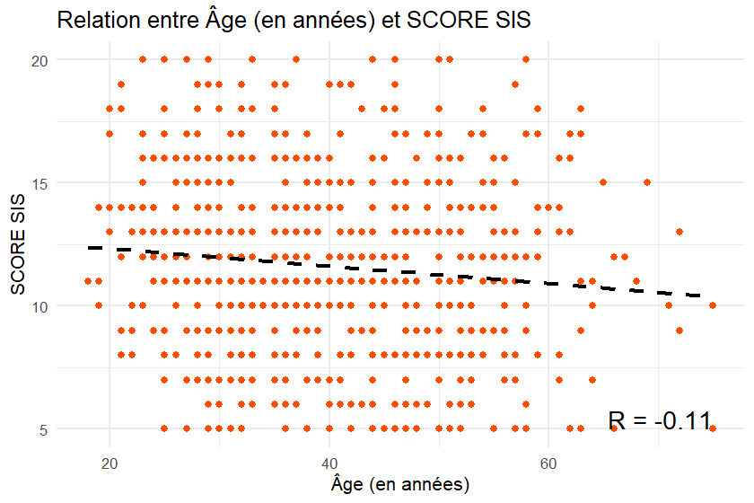

##### Fréquence consultation

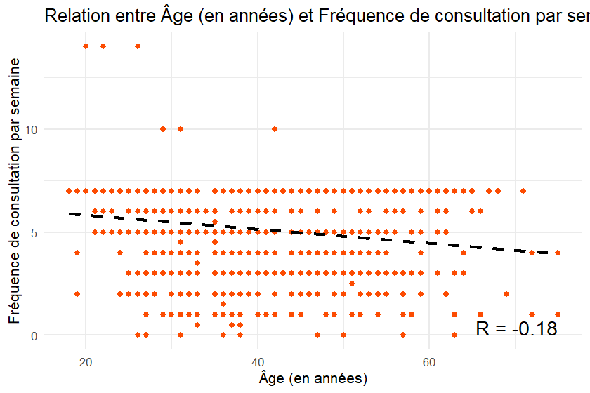

##### Fréquence publication

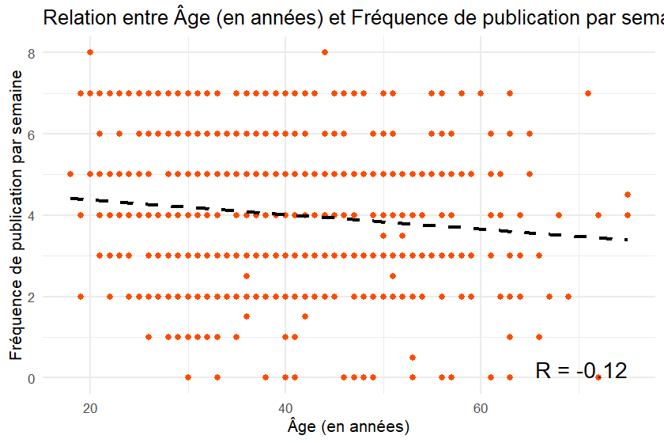

##### Ancienneté Strava

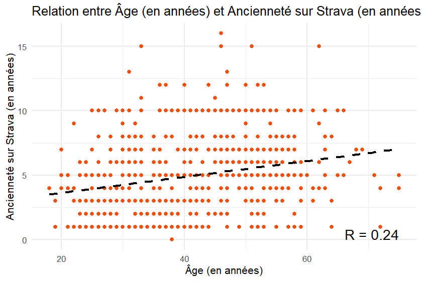

#### Test t de Student

| Variables | Student | P_Value | Significatif | Gratuit | Payant |
| --- | --- | --- | --- | --- | --- |
| Lien catégorie d’abonnement et Age | 1.82 | 0.0692365 | ≥ 0.05 | 40.48 | 38.9 |

### Sexe - Strava

La question est de savoir ici s’il existe des liens entre le sexe et l’utilisation de Strava.

On peut tester les liens entre les variables Strava suivantes et le sexe :

- Score SIS
- Score OSF
- Score exposition
- Appartenance à des clubs Strava
- Nombre de kudos reçus en moyenne par activité
- Nombre de publications par semaine (fréquence de publication)
- Nombre de consultations par semaine (fréquence de consultation)
- Nombre d’abonnés
- Nombre d’abonnements
- Ancienneté sur Strava
- Catégorie d’abonnement (gratuit/payant)

#### Test t de Student

| Variables | Student | P_Value | Significatif | Femme | Homme |
| --- | --- | --- | --- | --- | --- |
| Lien Sexe et SCORE_SIS | 1.72 | 0.0857790 | ≥ 0.05 | 11.83 | 11.37 |
| Lien Sexe et SCORE_OSF | -0.12 | 0.9064085 | ≥ 0.05 | 9.04 | 9.05 |
| Lien Sexe et SCORE_EXPO | 4.67 | 0.0000035 | <0.05 | 26.33 | 24.87 |
| Lien Sexe et Club_Strava | 2.21 | 0.0273560 | <0.05 | 3.06 | 2.23 |
| Lien Sexe et Kudos_reçus | 3.48 | 0.0005300 | <0.05 | 17.80 | 13.93 |
| Lien Sexe et Fréquence_publication | 4.33 | 0.0000169 | <0.05 | 4.28 | 3.72 |
| Lien Sexe et Fréquence_consultation | 2.72 | 0.0066679 | <0.05 | 5.35 | 4.92 |
| Lien Sexe et Nb_abonnés | 4.44 | 0.0000105 | <0.05 | 82.71 | 52.04 |
| Lien Sexe et Nb_abonnements | 4.80 | 0.0000019 | <0.05 | 81.29 | 53.35 |
| Lien Sexe et Ancienneté_Strava | 4.16 | 0.0000355 | <0.05 | 5.27 | 4.39 |

#### Visualisation graphique

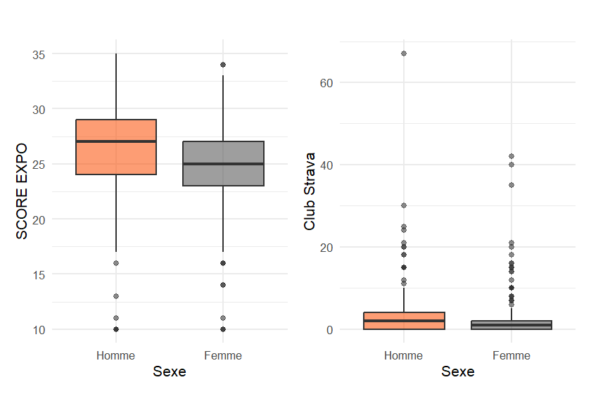

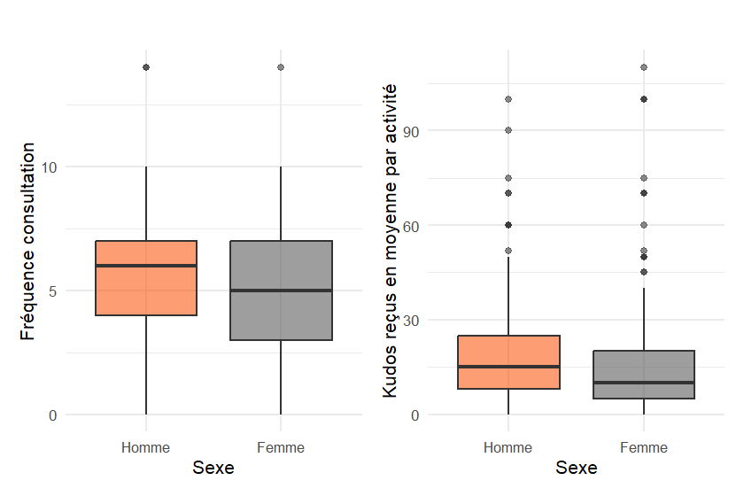

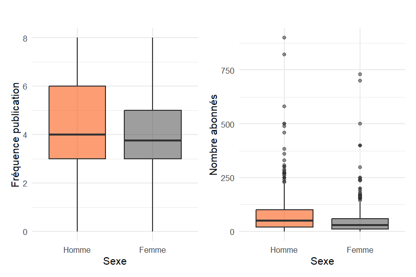

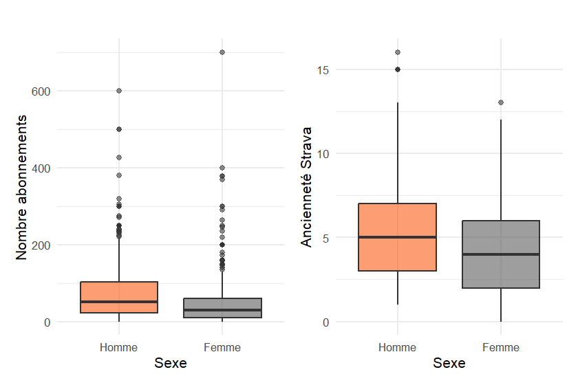

#### Khi² et Cramer

| Variable | Khi2_Indépendance | P_Value | Significatif | Coefficient_Cramer |
| --- | --- | --- | --- | --- |
| Lien entre Catégorie_abonnement et Sexe | 36.49 | 0 | <0.05 | 0.22 |

#### Visualisation graphique

| Catégorie_abonnement | Sexe | Observé | Attendu |
| --- | --- | --- | --- |
| Gratuit | Femme | 219 | 258.7919 |
| Payant | Femme | 181 | 141.2081 |
| Gratuit | Homme | 263 | 223.2081 |
| Payant | Homme | 82 | 121.7919 |

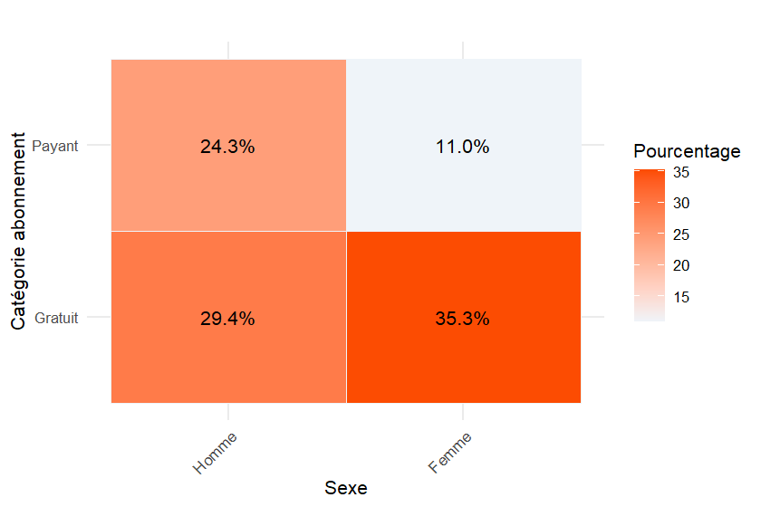

### Catégorie socio-professionnelle - Strava

La question est de savoir ici s’il existe des liens entre la catégorie socio-professionnelle et l’utilisation de Strava.

On peut tester les liens entre les variables Strava suivantes et les catégories socio-profesionnelles :

- Score SIS
- Score OSF
- Score exposition
- Appartenance à des clubs Strava
- Nombre de kudos reçus en moyenne par activité
- Nombre de publications par semaine (fréquence de publication)
- Nombre de consultations par semaine (fréquence de consultation)
- Nombre d’abonnés
- Nombre d’abonnements
- Ancienneté sur Strava
- Catégorie d’abonnement (gratuit/payant)

Les moyennes des variables suivantes sont significativement différentes entre les catégories socio-professionnelles (ANOVA, p < 0.01, hautement significatif) :

- Score SIS
- Fréquence consultation
- Ancienneté Strava

Les moyennes pour le score d’exposition sont significativement différentes entre les catégories socio-professionelles (ANOVA, p < 0.05, significatif).

Les tests posts hoc permettent de mettre en évidence que :

- les étudiants (8) ont des moyennes significativement plus élevées que les artisans (2) et professions intermédiaires (4) pour le score SIS, de même pour les ouvriers (6) par rapport aux professions intermédiaires (4).
- les étudiants (8) ont des moyennes significativement plus élevées que les artisans (2), les cadres (3), les professions intermédiaires (4), les employés (5) et les retraités (7) pour la fréquence de consultation.
- les étudiants (8) ont des moyennes significativement plus faibles que les artisans (2), les cadres (3) et les retraités (7) pour l’ancienneté sur Strava.

Il existe un lien entre la catégorie socio-professionelle et la catégorie d’abonnement (Khi² indépendance p<0.05, significatif, Cramer = 0,15, lien faible). Attention, il est à noter que le test de Khi² est partiellement valable étant donné que certaines sous-catégories ont des effectifs <5.

- Cadres : plus d’abonnements payants que prévu
- Employés : plus d’abonnements gratuits que prévu
- Artisans : plus d’abonnements payants que prévu
- Retraités : plus d’abonnements gratuits que prévu

#### ANOVA

| Variable | F_value | P_value | Significatif | Agriculteurs | Artisans | Cadres | Intermédiaires | Employés | Ouvriers | Retraités | Étudiants | Autres |
| --- | --- | --- | --- | --- | --- | --- | --- | --- | --- | --- | --- | --- |
| SCORE_SIS | 3.30 | 0.0010404 | < 0.05 | 14.333333 | 10.978723 | 11.561194 | 10.743590 | 11.649215 | 13.482759 | 10.722222 | 13.447368 | 10.833333 |
| SCORE_OSF | 1.20 | 0.2985715 | ≥ 0.05 | 8.333333 | 8.978723 | 9.083582 | 8.743590 | 8.984293 | 9.310345 | 9.555556 | 9.394737 | 8.166667 |
| SCORE_EXPO | 2.12 | 0.0322057 | < 0.05 | 23.666667 | 26.404255 | 25.426426 | 25.205128 | 25.631579 | 27.482759 | 25.470588 | 27.131579 | 22.500000 |
| Club_Strava | 0.67 | 0.7188337 | ≥ 0.05 | 1.333333 | 2.204546 | 2.735736 | 2.310811 | 2.967568 | 3.793103 | 1.352941 | 1.810811 | 2.400000 |
| Kudos_reçus | 0.58 | 0.7952622 | ≥ 0.05 | 9.333333 | 17.553192 | 15.859281 | 17.205128 | 15.021053 | 20.103448 | 14.500000 | 16.078947 | 15.500000 |
| Fréquence_publication | 1.56 | 0.1344090 | ≥ 0.05 | 2.666667 | 4.255319 | 4.013473 | 4.237179 | 3.872340 | 3.678571 | 3.638889 | 4.657895 | 3.666667 |
| Fréquence_consultation | 4.52 | 0.0000221 | < 0.05 | 5.333333 | 5.117021 | 5.143713 | 4.916667 | 4.944444 | 5.517857 | 4.111111 | 6.973684 | 4.833333 |
| Nb_abonnés | 1.20 | 0.2964900 | ≥ 0.05 | 23.333333 | 86.340425 | 70.734940 | 80.448718 | 60.031746 | 64.137931 | 36.055556 | 58.578947 | 119.500000 |
| Nb_abonnements | 0.75 | 0.6512382 | ≥ 0.05 | 28.333333 | 76.680851 | 69.490964 | 75.532467 | 62.815790 | 84.344828 | 45.411765 | 59.894737 | 80.833333 |
| Ancienneté_Strava | 2.92 | 0.0032954 | < 0.05 | 3.000000 | 5.638298 | 5.116766 | 4.441558 | 4.586387 | 5.137931 | 6.000000 | 3.421053 | 4.333333 |

#### Tests post hoc

| Variable | Comparison | diff | lwr | upr | p adj |
| --- | --- | --- | --- | --- | --- |
| SCORE_SIS | 8-2 | 2.468645 | 0.0022731 | 4.9350169 | 0.0495797 |
| SCORE_SIS | 6-4 | 2.739169 | 0.2802997 | 5.1980380 | 0.0162625 |
| SCORE_SIS | 8-4 | 2.703779 | 0.4672229 | 4.9403344 | 0.0056880 |
| Fréquence_consultation | 8-2 | 1.856663 | 0.4178809 | 3.2954449 | 0.0021335 |
| Fréquence_consultation | 8-3 | 1.829972 | 0.7008709 | 2.9590724 | 0.0000205 |
| Fréquence_consultation | 8-4 | 2.057018 | 0.7523010 | 3.3617340 | 0.0000404 |
| Fréquence_consultation | 8-5 | 2.029240 | 0.8567299 | 3.2017496 | 0.0000035 |
| Fréquence_consultation | 8-7 | 2.862573 | 0.9754848 | 4.7496614 | 0.0000985 |
| Ancienneté_Strava | 8-2 | -2.217245 | -4.1777584 | -0.2567321 | 0.0135809 |
| Ancienneté_Strava | 8-3 | -1.695714 | -3.2342491 | -0.1571785 | 0.0184065 |
| Ancienneté_Strava | 8-7 | -2.578947 | -5.1503317 | -0.0075630 | 0.0486691 |

#### Visualisation graphique

[figure not shown]

#### Khi² et Cramer

| Variable | Khi2_Indépendance | P_Value | Significatif | Coefficient_Cramer |
| --- | --- | --- | --- | --- |
| Lien entre Catégorie_abonnement et Catégorie | 17.71 | 0.0235162 | <0.05 | 0.15 |

#### Visualisation graphique

| Catégorie_abonnement | Catégorie | Observé | Attendu |
| --- | --- | --- | --- |
| Gratuit | Agriculteurs | 2 | 1.940940 |
| Payant | Agriculteurs | 1 | 1.059060 |
| Gratuit | Artisans | 26 | 30.408054 |
| Payant | Artisans | 21 | 16.591946 |
| Gratuit | Cadres | 199 | 216.738255 |
| Payant | Cadres | 136 | 118.261745 |
| Gratuit | Intermédiaires | 54 | 50.464430 |
| Payant | Intermédiaires | 24 | 27.535570 |
| Gratuit | Employés | 138 | 123.573154 |
| Payant | Employés | 53 | 67.426846 |
| Gratuit | Ouvriers | 19 | 18.762416 |
| Payant | Ouvriers | 10 | 10.237584 |
| Gratuit | Retraités | 15 | 11.645638 |
| Payant | Retraités | 3 | 6.354362 |
| Gratuit | Etudiants | 23 | 24.585235 |
| Payant | Etudiants | 15 | 13.414765 |
| Gratuit | Autres | 6 | 3.881879 |
| Payant | Autres | 0 | 2.118121 |

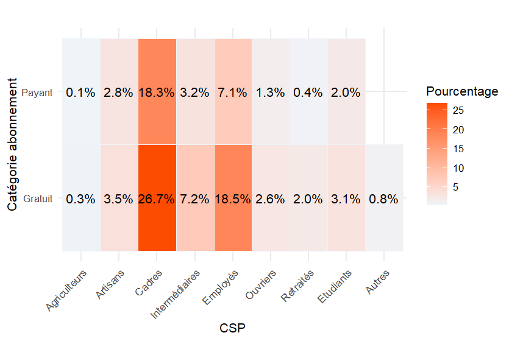

# Caractéristiques sportives

### Ancienneté et niveau

#### Répartition de l’ancienneté

| Moyenne | Médiane | Ecart_type |
| --- | --- | --- |
| 10.17383 | 8 | 9.18308 |

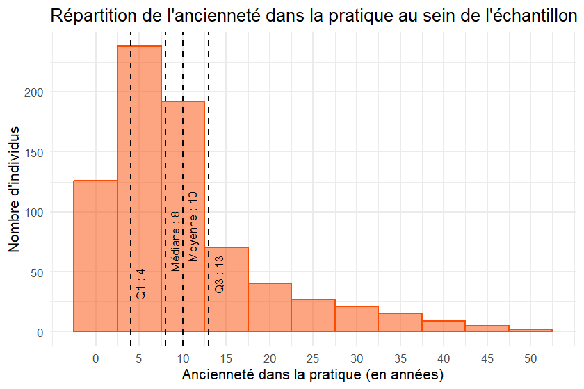

#### Répartition de l’ancienneté par sexe

| Sexe | Moyenne | Médiane | Ecart_type |
| --- | --- | --- | --- |
| Femme | 9.581159 | 8.0 | 8.329205 |
| Homme | 10.685000 | 7.5 | 9.842088 |

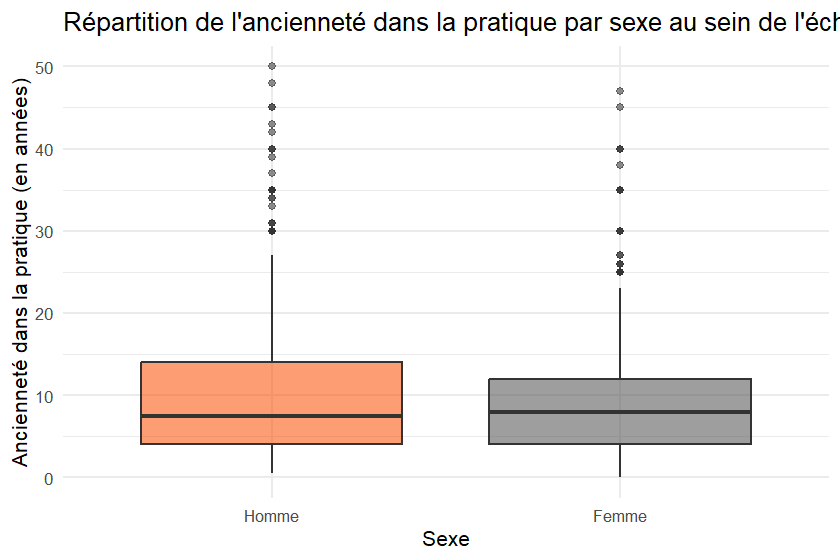

#### Niveau de course à pied

| Moyenne | Médiane | Ecart_type |
| --- | --- | --- |
| 2.461745 | 2 | 0.6791437 |

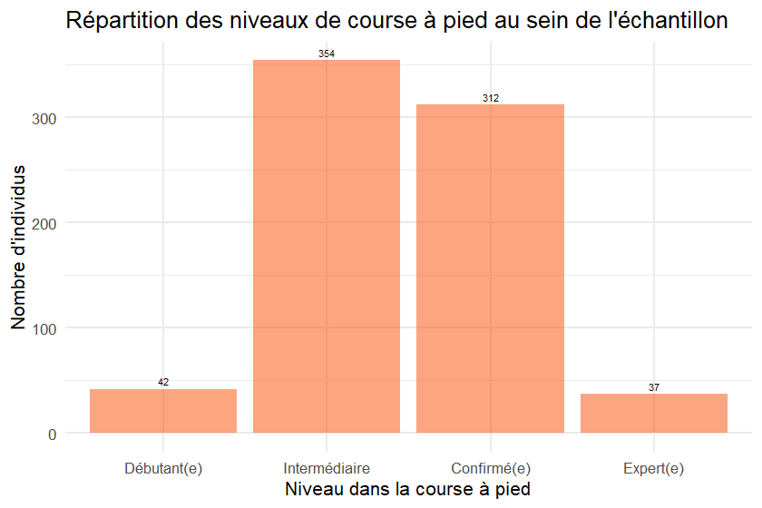

#### Niveau de course à pied par sexe

| Sexe | Moyenne | Médiane | Ecart_type |
| --- | --- | --- | --- |
| Femme | 2.249275 | 2 | 0.6207701 |
| Homme | 2.645000 | 3 | 0.6746205 |

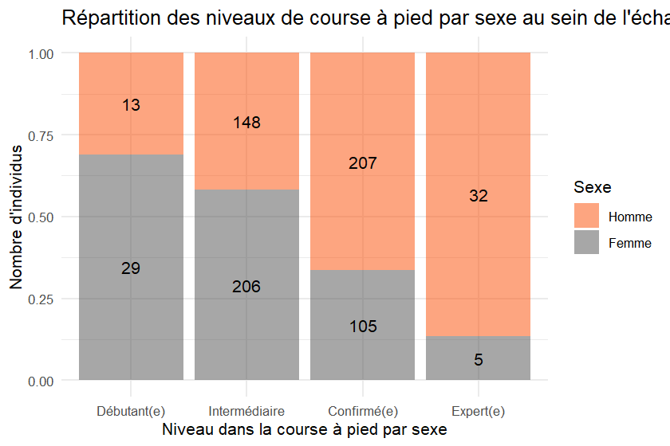

### Entraînement

#### Fréquence d’entraînement

| Moyenne | Médiane | Ecart_type |
| --- | --- | --- |
| 3.372312 | 3 | 1.288666 |

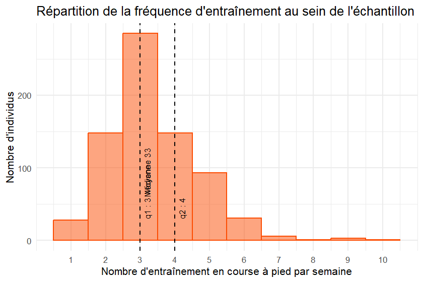

#### Fréquence d’entraînement par sexe

| Sexe | Moyenne | Médiane | Ecart_type |
| --- | --- | --- | --- |
| Femme | 2.976812 | 3 | 1.017027 |
| Homme | 3.714286 | 3 | 1.397619 |

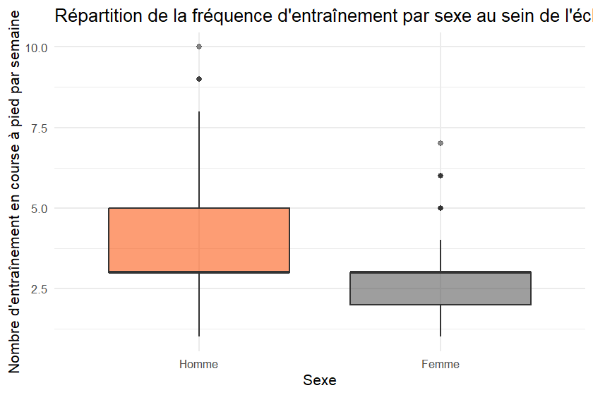

#### Volume d’entraînement

| Moyenne | Médiane | Ecart_type |
| --- | --- | --- |
| 39.14266 | 35 | 20.14104 |

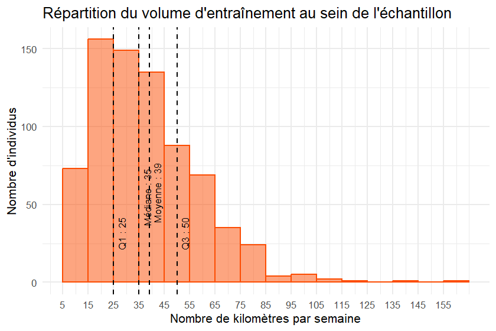

#### Volume d’entraînement par sexe

| Sexe | Moyenne | Médiane | Ecart_type |
| --- | --- | --- | --- |
| Femme | 31.77843 | 30 | 15.49431 |
| Homme | 45.45750 | 40 | 21.49449 |

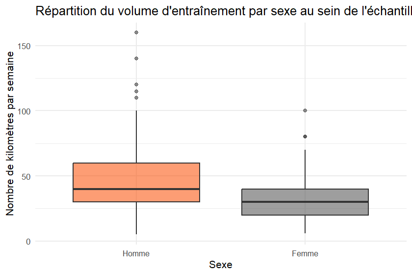

#### Volume et fréquence

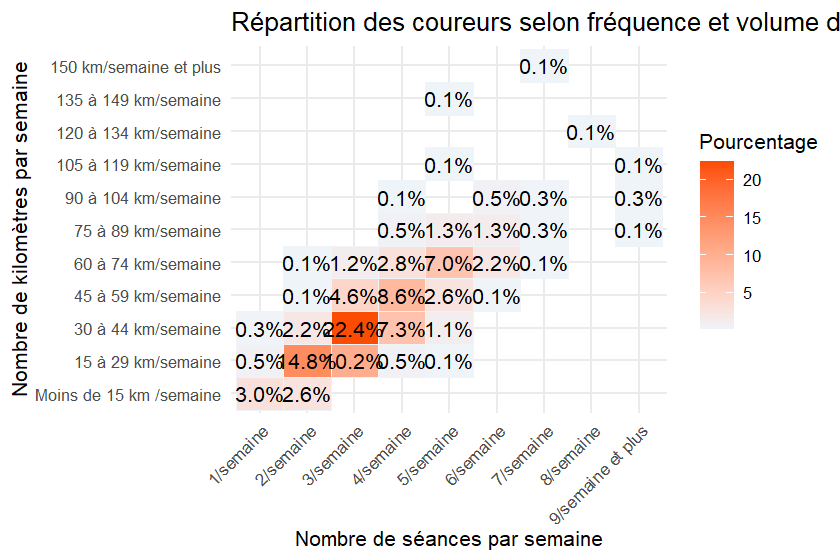

### Compétitions

#### Nombre de compétitions par an

| Moyenne | Médiane | Ecart_type |
| --- | --- | --- |
| 4.40457 | 3 | 3.888282 |

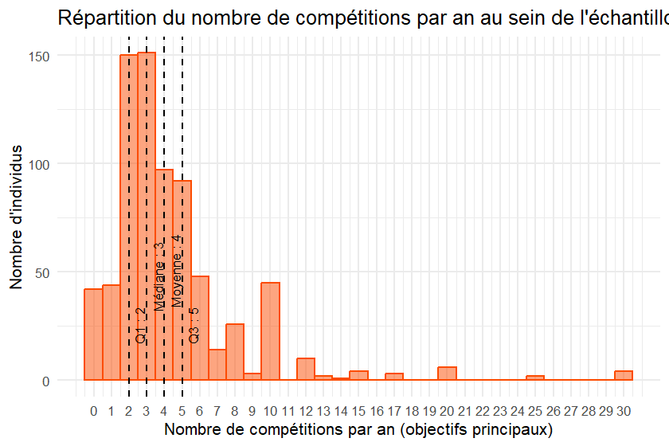

#### Nombre de compétitions par an par sexe

| Sexe | Moyenne | Médiane | Ecart_type |
| --- | --- | --- | --- |
| Femme | 4.261628 | 3 | 4.034275 |
| Homme | 4.527500 | 4 | 3.758932 |

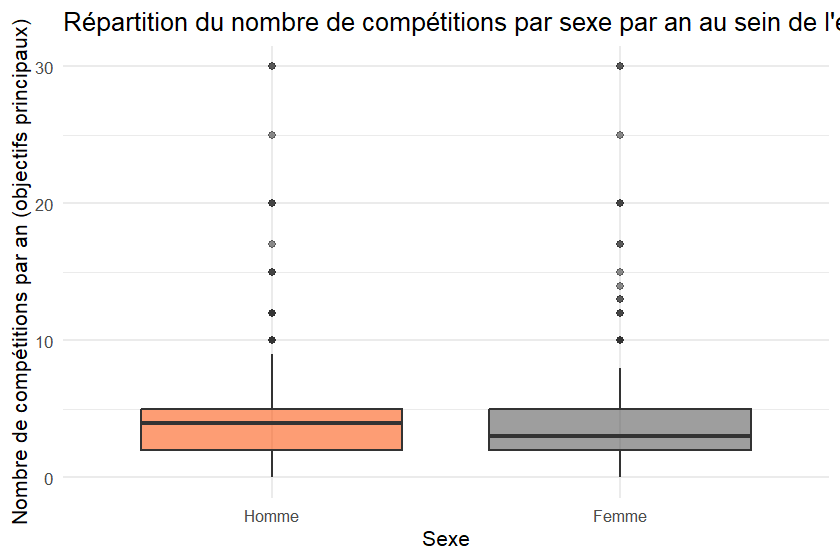

#### Objectif 2025

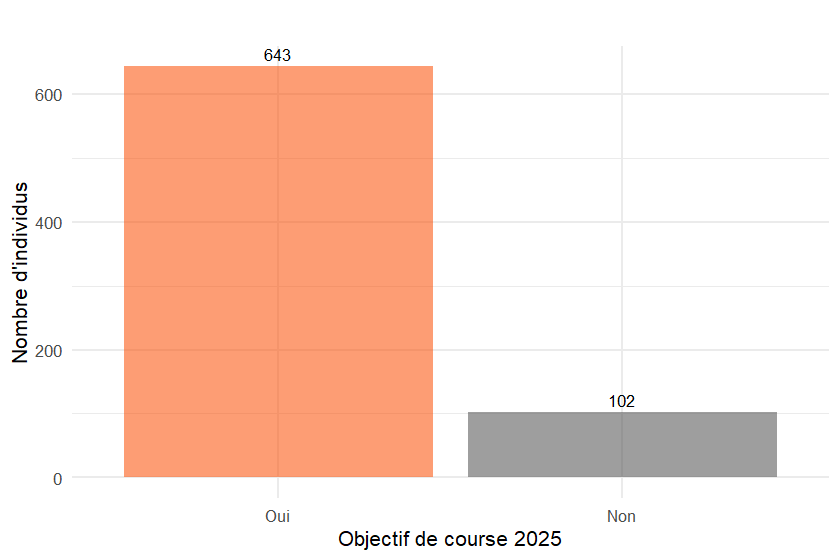

#### Type objectif 2025

```
## Le nombre d'individus considérés 643.
```

[figure not shown]

### Caractéristiques de la pratique

#### Lieu de pratique

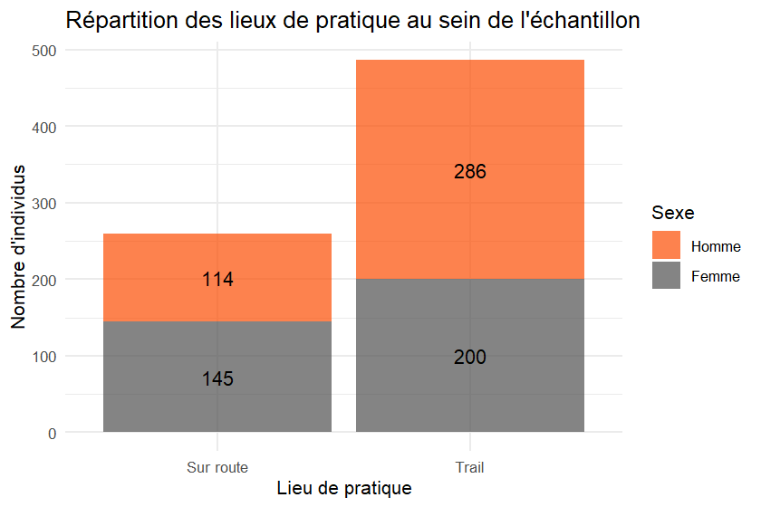

#### Club

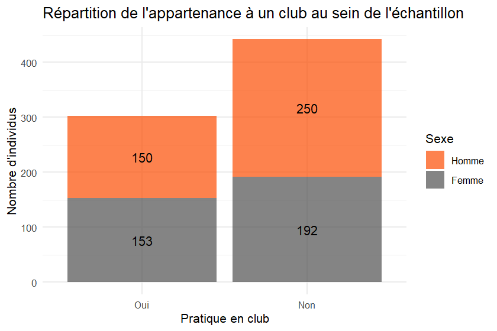

#### Mode

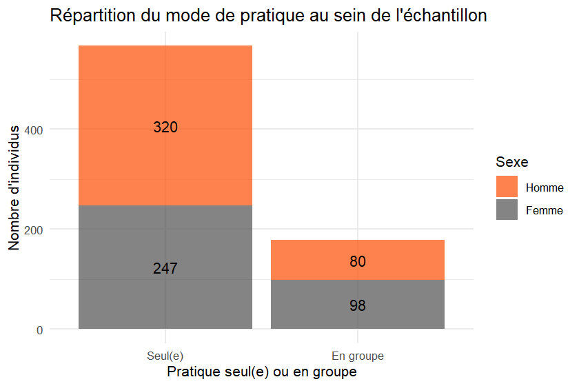

#### Type coureur

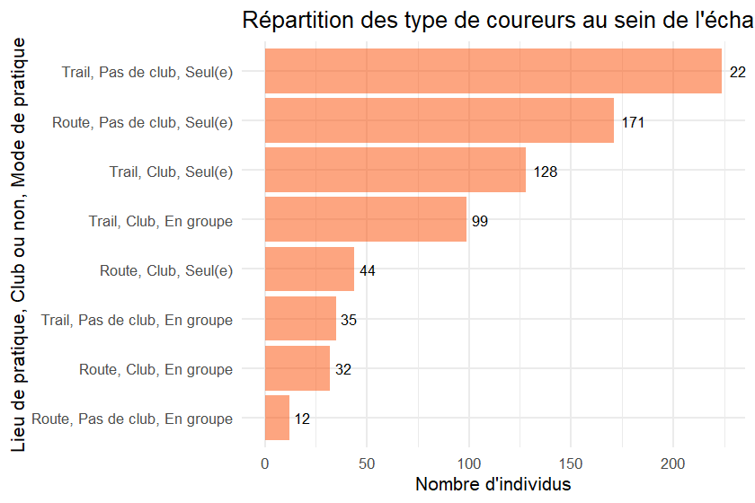

#### Coach

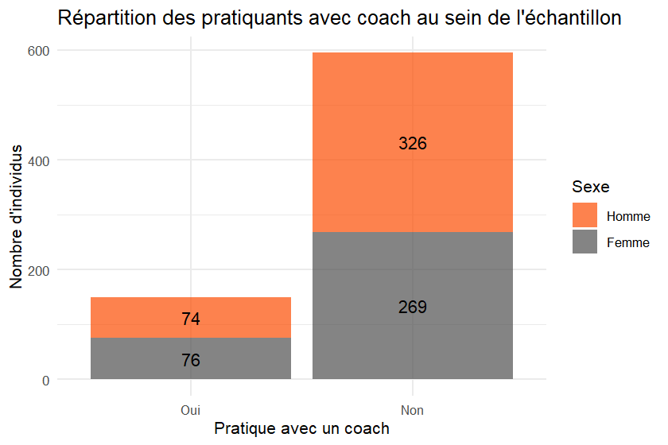

#### Programme d’entraînement

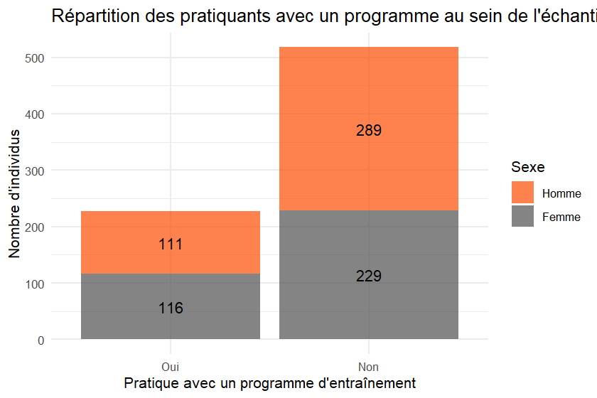

### Blessure

#### Blessure

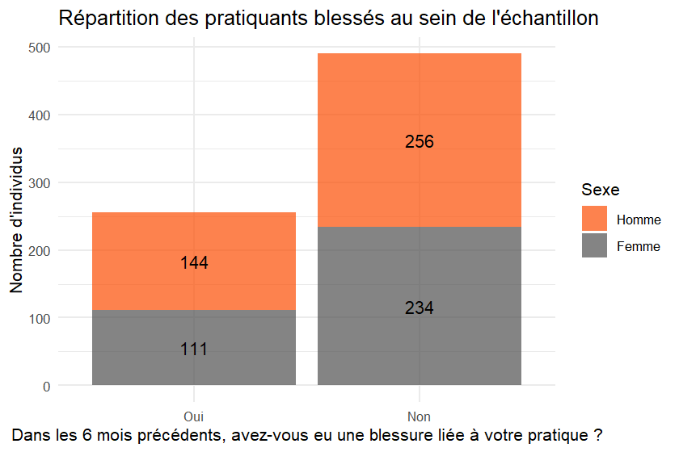

#### Pause

```
## Le nombre d'individus considérés 255.
```

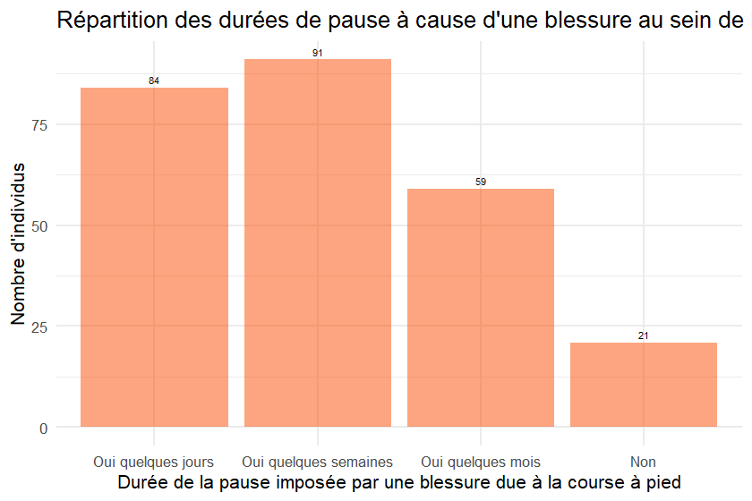

# Lien utilisation de Strava - caractéristiques sportives (hypothèse 1)

Il s’agit de savoir s’il y a un lien entre l’utilisation de Strava et les caractéristiques sportives.

**Rappel de l’hypothèse 1 : plus les coureurs amateurs utilisent Strava, plus le nombre de kilomètres et d’entraînements par semaine, et le nombre de compétitions par an sont élevés.**

On peut tester les liens entre les variables Strava suivantes :

- Score SIS
- Score OSF
- Score exposition
- Appartenance à des clubs Strava
- Nombre de kudos reçus en moyenne par activité
- Nombre de publications par semaine (fréquence de publication)
- Nombre de consultations par semaine (fréquence de consultation)
- Nombre d’abonnés
- Nombre d’abonnements
- Ancienneté sur Strava
- Catégorie d’abonnement (gratuit/payant)

Avec les variables sportives suivantes :

- nombre de kilomètres par semaine (volume par semaine)
- nombre d’entraînements par semaine (fréquence entraînement)
- nombre de compétitions par an
- niveau
- type de coureur (trail/route, club/pas club, seul/en groupe)
- suivi d’un programme d’entraînement
- accompagnement par un coach
- type d’objectif 2025 s’il y en a un
- blessure ou non liée à la course à pied dans les 6 derniers mois
- durée de la pause d’une blessure liée à la course à pied

### Une première approche

#### Influence de Strava

| Moyenne | Médiane | Ecart_type |
| --- | --- | --- |
| 2.132886 | 2 | 0.9403187 |

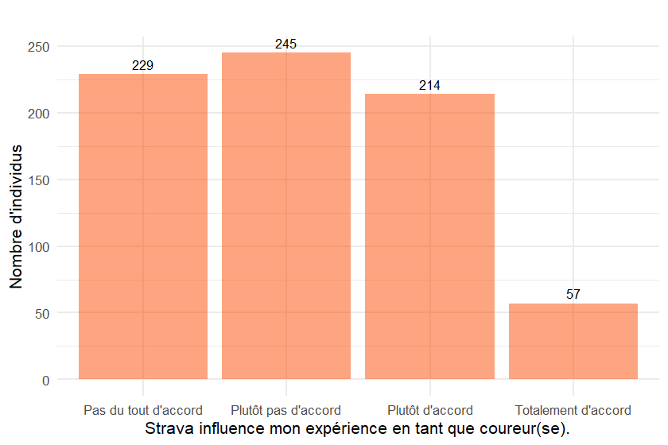

#### Performance

[output not shown]

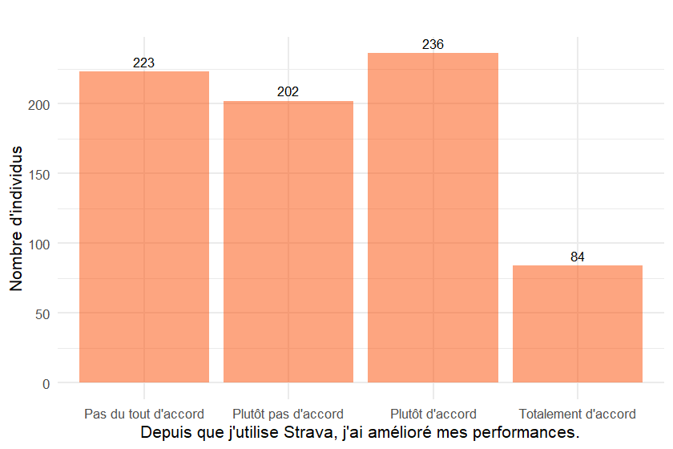

#### Fréquence

| Moyenne | Médiane | Ecart_type |
| --- | --- | --- |
| 2.09396 | 2 | 1.022215 |

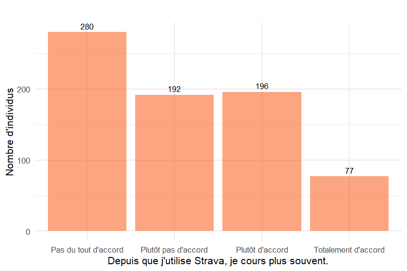

#### Kilomètres

| Moyenne | Médiane | Ecart_type |
| --- | --- | --- |
| 2.045638 | 2 | 1.010994 |

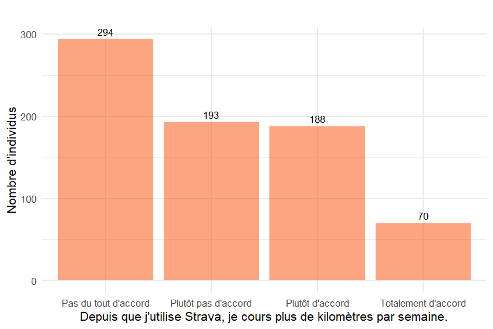

#### Compétitions

| Moyenne | Médiane | Ecart_type |
| --- | --- | --- |
| 1.558389 | 1 | 0.8688997 |

[figure not shown]

#### Ignorance blessure

| Moyenne | Médiane | Ecart_type |
| --- | --- | --- |
| 1.347651 | 1 | 0.6464943 |

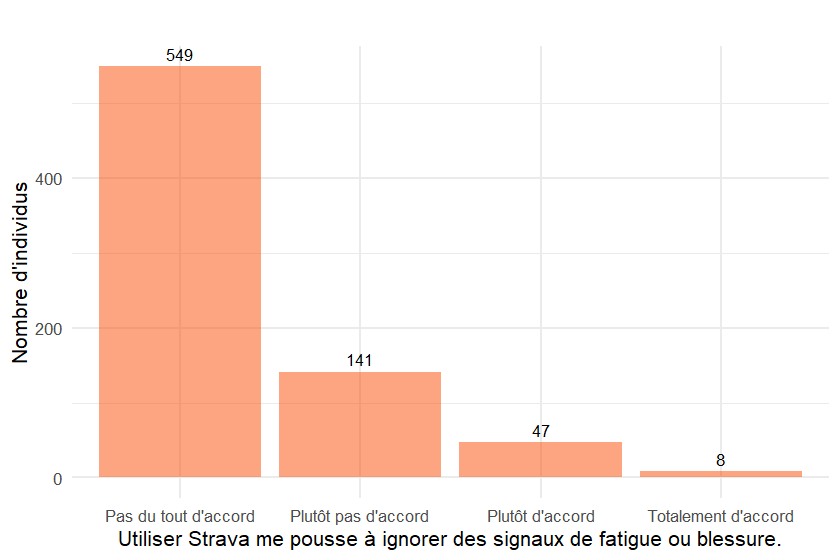

#### Ajout entraînement

| Moyenne | Médiane | Ecart_type |
| --- | --- | --- |
| 1.695302 | 1 | 0.8993976 |

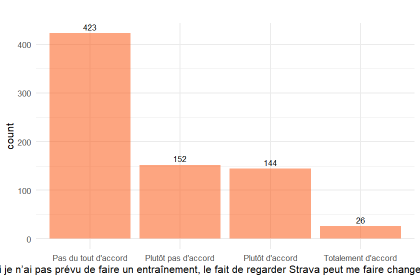

#### Changement entraînement

```
## Le nombre d'individus considérés 438.
```

| Moyenne | Médiane | Ecart_type |
| --- | --- | --- |
| 1.121005 | 1 | 0.4294288 |

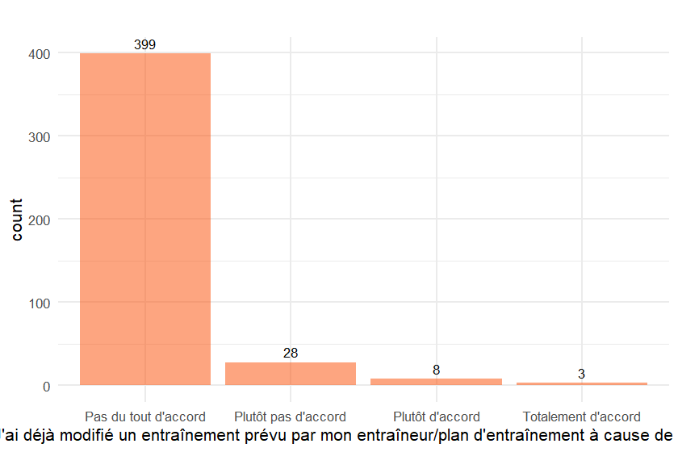

#### Changement programme

```
## Le nombre d'individus considérés 438.
```

| Moyenne | Médiane | Ecart_type |
| --- | --- | --- |
| 1.114679 | 1 | 0.4131907 |

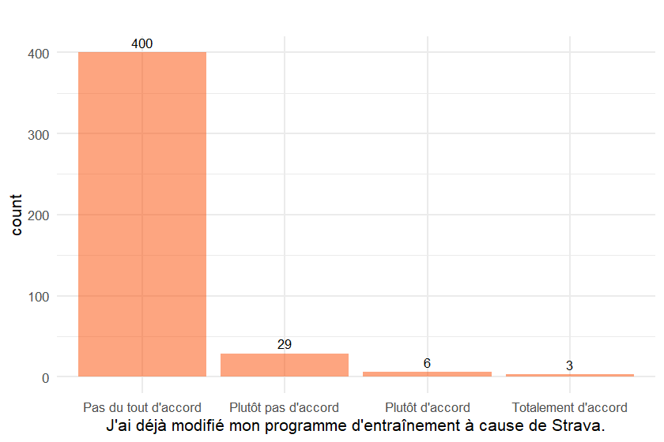

### Statistiques

```
## Rappel : l'alpha de Cronbach sur le SIS est 0.763630836835257, sur le score OSF est 0.601301166919539 et sur le score EXPO 0.78033975325236.
```

#### Corrélations

##### Nombre d’entraînement par semaine

| Variable | Corr_Frequence_pratique | P_value | Significatif |
| --- | --- | --- | --- |
| Score SIS | 0.08 | 0.0296 | <0.05 |
| Score OSF | 0.03 | 0.4440 | ≥0.05 |
| Score d’Exposition | 0.12 | 0.0010 | <0.05 |
| Appartenance à un club Strava | 0.2 | 0.0000 | <0.05 |
| Nombre de kudos reçus par activité | 0.28 | 0.0000 | <0.05 |
| Fréquence de publication | 0.61 | 0.0000 | <0.05 |
| Fréquence de consultation | 0.24 | 0.0000 | <0.05 |
| Nombre d’abonnés | 0.36 | 0.0000 | <0.05 |
| Nombre d’abonnements | 0.31 | 0.0000 | <0.05 |
| Ancienneté sur Strava (années) | 0.09 | 0.0133 | <0.05 |

##### Nombre de kilomètres par semaine

| Variable | Corr_Kilomètres | P_value | Significatif |
| --- | --- | --- | --- |
| Score SIS | 0.03 | 0.3990 | ≥0.05 |
| Score OSF | 0.02 | 0.5678 | ≥0.05 |
| Score d’Exposition | 0.13 | 0.0006 | <0.05 |
| Appartenance à un club Strava | 0.2 | 0.0000 | <0.05 |
| Nombre de kudos reçus par activité | 0.32 | 0.0000 | <0.05 |
| Fréquence de publication | 0.56 | 0.0000 | <0.05 |
| Fréquence de consultation | 0.17 | 0.0000 | <0.05 |
| Nombre d’abonnés | 0.38 | 0.0000 | <0.05 |
| Nombre d’abonnements | 0.35 | 0.0000 | <0.05 |
| Ancienneté sur Strava (années) | 0.16 | 0.0000 | <0.05 |

##### Compétitions

| Variable | Corr_Compétitions | P_value | Significatif |
| --- | --- | --- | --- |
| Score SIS | 0.18 | 0.0000 | <0.05 |
| Score OSF | 0.19 | 0.0000 | <0.05 |
| Score d’Exposition | 0.18 | 0.0000 | <0.05 |
| Appartenance à un club Strava | 0.16 | 0.0000 | <0.05 |
| Nombre de kudos reçus par activité | 0.26 | 0.0000 | <0.05 |
| Fréquence de publication | 0.21 | 0.0000 | <0.05 |
| Fréquence de consultation | 0.15 | 0.0000 | <0.05 |
| Nombre d’abonnés | 0.18 | 0.0000 | <0.05 |
| Nombre d’abonnements | 0.21 | 0.0000 | <0.05 |
| Ancienneté sur Strava (années) | -0.04 | 0.2395 | ≥0.05 |

#### Visualisation graphique

##### Kudos reçus - Kilomètres par semaine

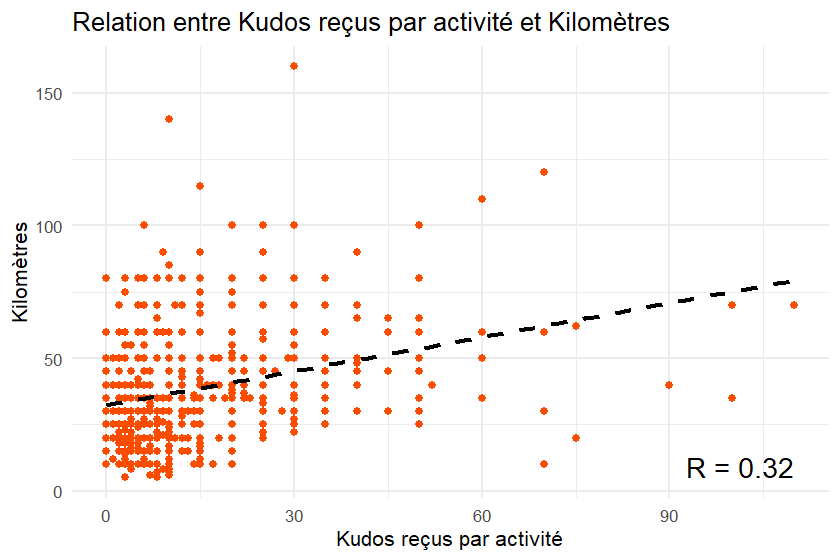

##### Fréquence de publication - Kilomètres par semaine

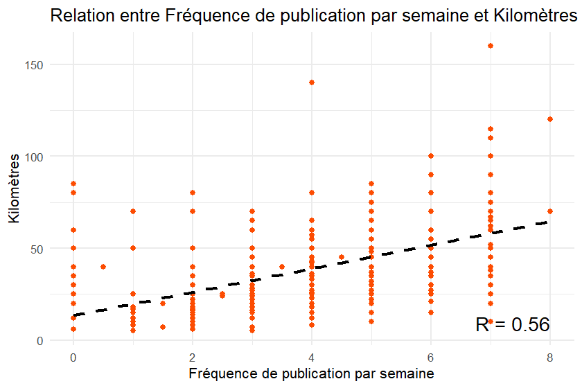

##### Fréquence de publication - Fréquence d’entraînement

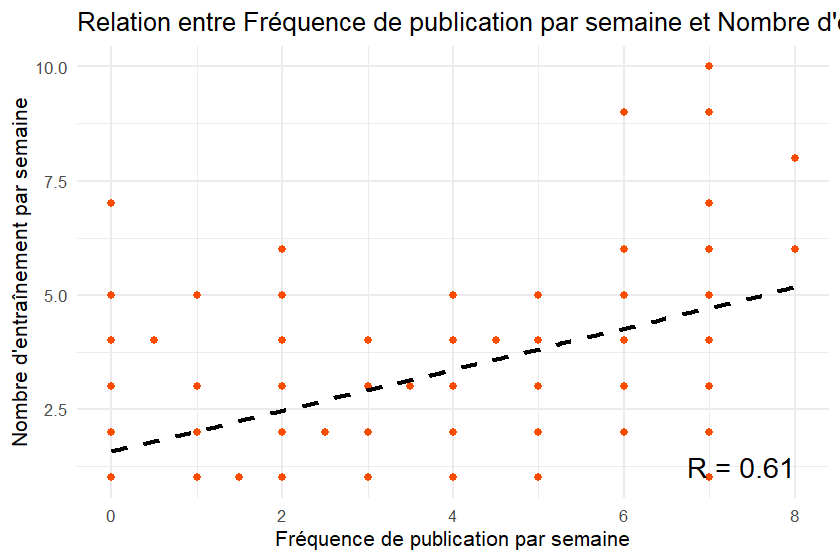

##### Nombre d’abonnés - Fréquence d’entraînement

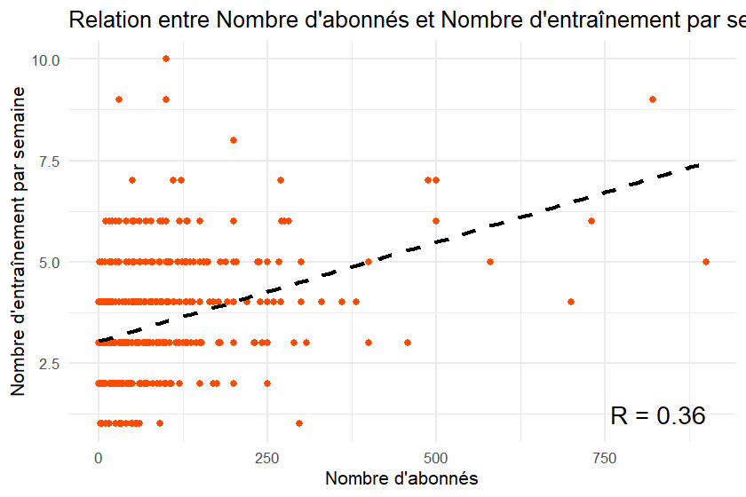

##### Nombres d’abonnés - Kilomètres par semaine

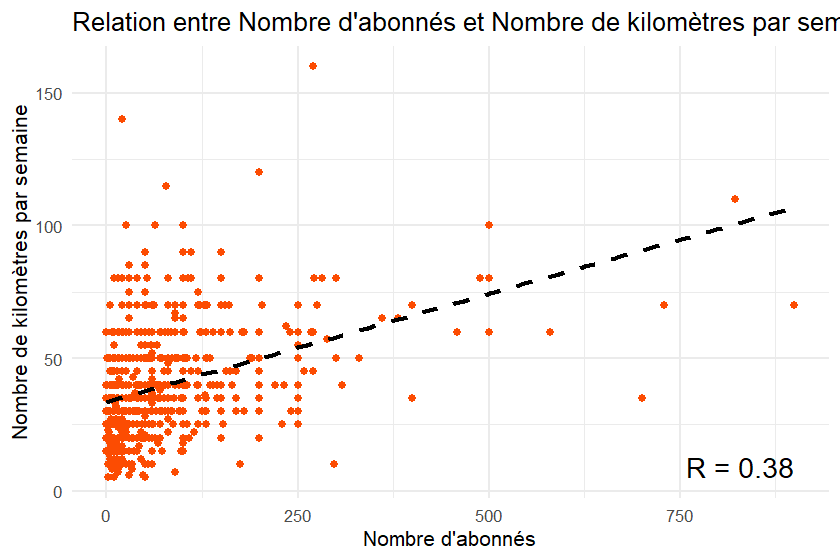

##### Nombre d’abonnements - Fréquence d’entraînement

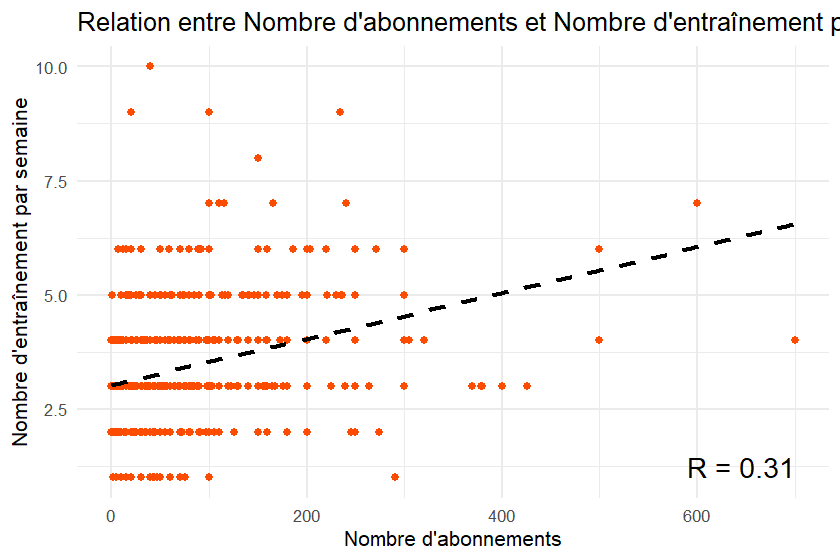

##### Nombres d’abonnements - Kilomètres par semaine

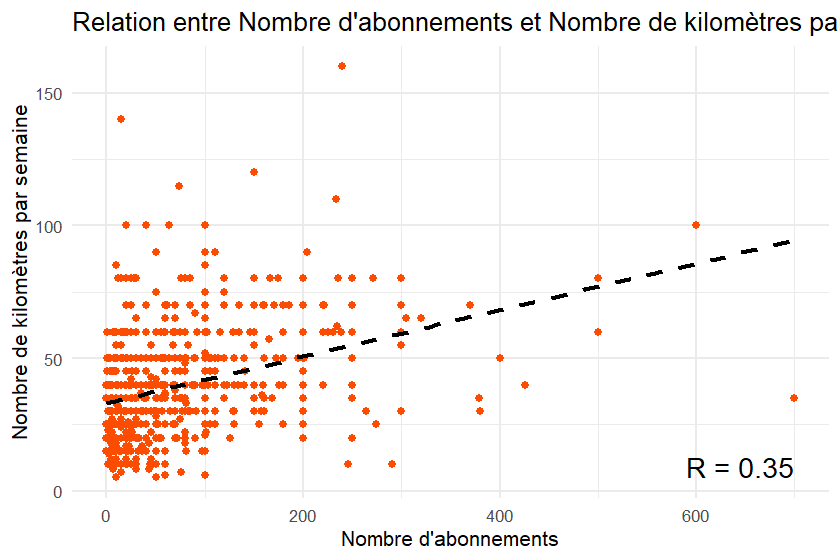

#### Khi² et Cramer

| Variable | Khi2_indépendance | P.value | Significatif | Coefficient_Cramer |
| --- | --- | --- | --- | --- |
| Lien catégorie abonnement et niveau | 16.56 | 0.0008688 | < 0.05 | 0.15 |
| Lien catégorie abonnement et type coureur | 25.27 | 0.0006792 | < 0.05 | 0.18 |
| Lien catégorie abonnement et coach | 2.67 | 0.1022671 | ≥ 0.05 | 0.06 |
| Lien catégorie abonnement et programme | 3.58 | 0.0583856 | ≥ 0.05 | 0.07 |
| Lien catégorie abonnement et objectif | 37.12 | 0.0000002 | < 0.05 | 0.22 |
| Lien catégorie abonnement et blessure | 2.35 | 0.1256023 | ≥ 0.05 | 0.06 |
| Lien catégorie abonnement et pause | 7.60 | 0.1075199 | ≥ 0.05 | 0.10 |

#### Visualisation graphique

##### Niveau et catégorie d’abonnement

| Catégorie_abonnement | Niveau | Observé | Attendu |
| --- | --- | --- | --- |
| Gratuit | Débutant | 32 | 27.17315 |
| Payant | Débutant | 10 | 14.82685 |
| Gratuit | Intermédiaire | 248 | 229.03087 |
| Payant | Intermédiaire | 106 | 124.96913 |
| Gratuit | Confirmé | 185 | 201.85772 |
| Payant | Confirmé | 127 | 110.14228 |
| Gratuit | Expert | 17 | 23.93826 |
| Payant | Expert | 20 | 13.06175 |

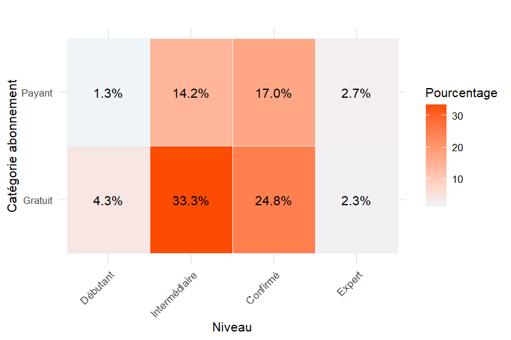

##### Type de coureur et catégorie d’abonnement

| Catégorie_abonnement | Type_coureur | Observé | Attendu |
| --- | --- | --- | --- |
| Gratuit | Route, club, seul | 32 | 28.467114 |
| Payant | Route, club, seul | 12 | 15.532886 |
| Gratuit | Route, club, en groupe | 25 | 20.703356 |
| Payant | Route, club, en groupe | 7 | 11.296644 |
| Gratuit | Route, pas de club, seul | 113 | 110.633557 |
| Payant | Route, pas de club, seul | 58 | 60.366443 |
| Gratuit | Route, pas de club, en groupe | 10 | 7.763758 |
| Payant | Route, pas de club, en groupe | 2 | 4.236242 |
| Gratuit | Trail, club, seul | 75 | 82.813423 |
| Payant | Trail, club, seul | 53 | 45.186577 |
| Gratuit | Trail, club, en groupe | 75 | 64.051007 |
| Payant | Trail, club, en groupe | 24 | 34.948993 |
| Gratuit | Tail, pas de club, seul | 124 | 144.923490 |
| Payant | Tail, pas de club, seul | 100 | 79.076510 |
| Gratuit | Trail, pas de club, en groupe | 28 | 22.644295 |
| Payant | Trail, pas de club, en groupe | 7 | 12.355705 |

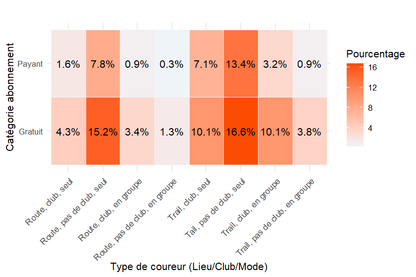

##### Objectif et catégorie d’abonnement

| Catégorie_abonnement | Objectif_KM | Observé | Attendu |
| --- | --- | --- | --- |
| Gratuit | Pas d’objectif | 78 | 60.16913 |
| Payant | Pas d’objectif | 15 | 32.83087 |
| Gratuit | 20 K | 129 | 114.51544 |
| Payant | 20 K | 48 | 62.48456 |
| Gratuit | 50 K | 166 | 172.09664 |
| Payant | 50 K | 100 | 93.90336 |
| Gratuit | 100 K | 74 | 86.04832 |
| Payant | 100 K | 59 | 46.95168 |
| Gratuit | 100 M | 35 | 49.17047 |
| Payant | 100 M | 41 | 26.82953 |

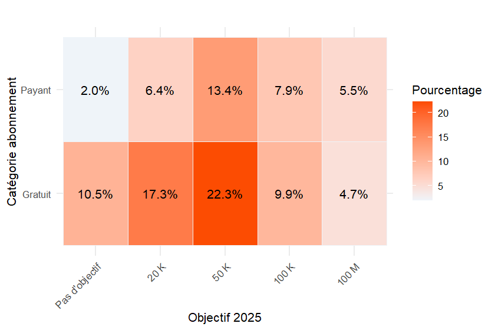

#### Test t de Student

| Variable | Student | P_value | Significatif | Gratuit | Payant |
| --- | --- | --- | --- | --- | --- |
| Catégorie d’abonnement et entrainement par semaine | -7.202226 | 0.0000000 | <0.05 | 3.128898 | 3.817490 |
| Catégorie d’abonnement et kilomètres par semaine | -5.761883 | 0.0000000 | <0.05 | 36.066528 | 44.790076 |
| Catégorie d’abonnement et nombre de compétitions | -2.785636 | 0.0054786 | <0.05 | 4.112266 | 4.939164 |

#### Visualisation graphique

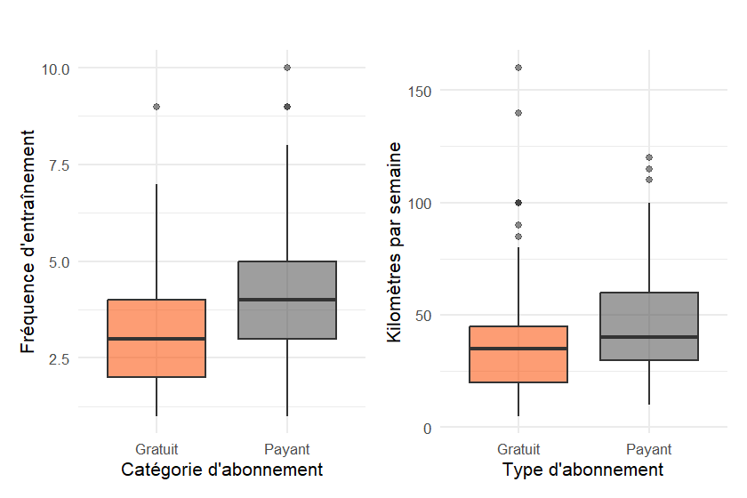

### Conclusion hypothèse 1

**Rappel de l’hypothèse 1 : plus les coureurs amateurs utilisent Strava, plus le nombre de kilomètres par semaine, d’entraînements par semaine, et de compétitions par an sont élevés.**

Le nombre de kilomètres par semaine est :

- faiblement corrélé au score d’exposition (0.13), à l’appartenance d’un club strava (0.20), à la fréquence de consultation (0.17) et l’ancienneté sur Strava (0.16)
- moyennenement corrélé au nombre de kudos reçus par activité (0.32), au nombre d’abonnés (0.38) et au nombre d’abonnements (0.35)
- corrélé de manière élévée avec la fréquence de publication (0.56)

Le nombre d’entraînement par semaine est :

- faiblement corrélé au score d’exposition (0.12), à l’appartenance d’un club strava (0.20), au nombre de kudos reçus par activité (0.28) et à la fréquence de consultation (0.24).
- moyennement corrélé au nombre d’abonnés (0.36) et au nombre d’abonnements (0.31)
- corrélé de manière élévée avec la fréquence de publication (0.61)

*Pour rappel, l’un des buts principaux d’utilisation de Strava et l’une des fonctionnalités les plus appréciées est l’enregistrement d’une activité, ce qui déclenche automatiquement sur Strava la publication de l’activité.*

Le nombre de compétitions par an est faiblement corrélé à l’ensemble des variables sauf l’ancienneté sur Strava où il n’y a pas de corrélation : l’utilisation de Strava influence peu la participation aux compétitions.

Il y a un lien entre la catégorie d’abonnement et :

- le niveau (Khi² indépendance, p<0.01, hautement significatif, Cramer = 0.15, lien faible). Les niveaux débutants et niveau intermédiaires prennent plus d’abonnements gratuits que prévus, les niveaux confirmés et experts prennent plus d’abonnements payants que prévus.
- le type de coureur (Khi² indépendance, p<0.01, Cramer = 0.18, lien faible). Les traileurs qui courent le plus souvent seul, appartenant à un club ou non prennent plus l’abonnement payant. Les autres types de coureurs prennent plus l’abonnement gratuit.
- le type d’objectif principal en 2025 (Khi² indépendance, p<0.01, Cramer = 0.22, lien faible). Les coureurs sans objectif ou avec un objectif de 20 kilomètres prennent plus l’abonnement gratuit. Les coureurs avec un objectif de 50 kilomètres ou plus prennent plus l’abonnement payant.

Les moyennes du nombre d’entraînements par semaine, du nombre de kilomètres par semaine et du nombre de compétitions par an sont significativement plus élévées chez les utilisateurs ayant un compte payant (test t de Student, p<0.01, hautement significatif).